# Exploring gapminder & dplyr

Ni Jie

2/8/2021

# Loading Packages

```r
library(gapminder)
library(palmerpenguins)
library(ggplot2)
library(tidyverse)
library(dplyr)
View(gapminder)
```

[output not shown]

```r
View(palmerpenguins::penguins)
```

[output not shown]

# Exercise 1: Basic dplyr

1.1 Use filter() to subset the gapminder data to three countries of your choice in the 1970’s.

```r
subset1970 <- filter(gapminder, country %in% c("Austria", "Benin", "Brazil") & year >=1970 & year < 1980)
subset1970
```

```
## # A tibble: 6 x 6
##   country continent  year lifeExp       pop gdpPercap
##   <fct>   <fct>     <int>   <dbl>     <int>     <dbl>
## 1 Austria Europe     1972    70.6   7544201    16662.
## 2 Austria Europe     1977    72.2   7568430    19749.
## 3 Benin   Africa     1972    47.0   2761407     1086.
## 4 Benin   Africa     1977    49.2   3168267     1029.
## 5 Brazil  Americas   1972    59.5 100840058     4986.
## 6 Brazil  Americas   1977    61.5 114313951     6660.
```

1.2 Use the pipe operator %>% to select “country” and “gdpPercap” from your filtered dataset in 1.1.

```r
subset1970 %>%
  select(country, gdpPercap)
```

```
## # A tibble: 6 x 2
##   country gdpPercap
##   <fct>       <dbl>
## 1 Austria    16662.
## 2 Austria    19749.
## 3 Benin       1086.
## 4 Benin       1029.
## 5 Brazil      4986.
## 6 Brazil      6660.
```

1.3 Make a new variable in gapminder for the change in life expectancy from the previous measurement. Filter this table to show all of the entries that have experienced a drop in life expectancy.

```r
gapminder %>%
  mutate(changeLifeExp = lifeExp - lag(lifeExp)) %>%
  filter(changeLifeExp<0)
```

```
## # A tibble: 221 x 7
##    country    continent  year lifeExp      pop gdpPercap changeLifeExp
##    <fct>      <fct>     <int>   <dbl>    <int>     <dbl>         <dbl>
##  1 Albania    Europe     1992    71.6  3326498     2497.        -0.419
##  2 Algeria    Africa     1952    43.1  9279525     2449.       -33.3
##  3 Angola     Africa     1952    30.0  4232095     3521.       -42.3
##  4 Angola     Africa     1987    39.9  7874230     2430.        -0.036
##  5 Australia  Oceania    1952    69.1  8691212    10040.        -6.20
##  6 Austria    Europe     1952    66.8  6927772     6137.       -14.4
##  7 Bahrain    Asia       1952    50.9   120447     9867.       -28.9
##  8 Bangladesh Asia       1952    37.5 46886859      684.       -38.2
##  9 Benin      Africa     1952    38.2  1738315     1063.       -41.2
## 10 Benin      Africa     2002    54.4  7026113     1373.        -0.371
## # … with 211 more rows
```

1.4 Filter gapminder so that it shows the max GDP per capita experienced by each country.

```r
gapminder %>%
  group_by(country) %>%
  summarise(gdpPercap = max(gdpPercap))
```

```
## # A tibble: 142 x 2
##    country     gdpPercap
##  * <fct>           <dbl>
##  1 Afghanistan      978.
##  2 Albania         5937.
##  3 Algeria         6223.
##  4 Angola          5523.
##  5 Argentina      12779.
##  6 Australia      34435.
##  7 Austria        36126.
##  8 Bahrain        29796.
##  9 Bangladesh      1391.
## 10 Belgium        33693.
## # … with 132 more rows
```

1.5 Produce a scatterplot of Canada’s life expectancy vs. GDP per capita using ggplot2, without defining a new variable. That is, after filtering the gapminder data set, pipe it directly into the ggplot() function. In your plot, put GDP per capita on a log scale.

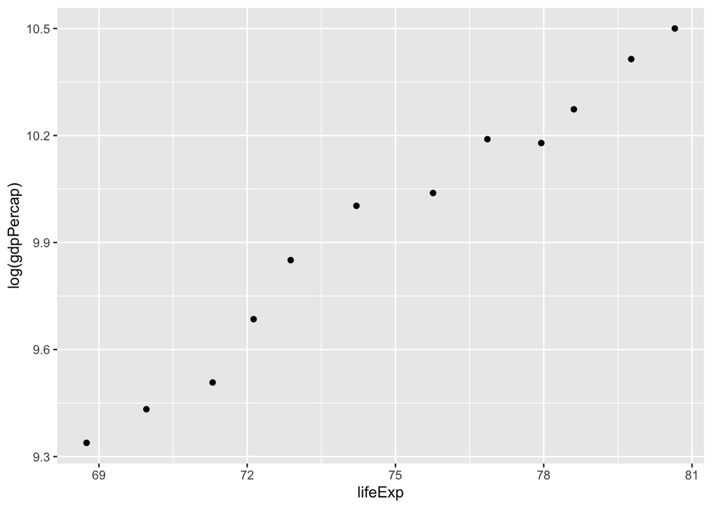

```r
gapminder %>%
  filter(country == "Canada") %>%
  ggplot(aes(x=lifeExp, y=log(gdpPercap))) +
  geom_point()
```

# Exercise 2: Explore two variables with dplyr and ggplot2

2.1 I use “palmerpenguins::penguins” dataset and two quantitative variables that are “bill length” and “flipper length”.

```r
#descriptive table
palmerpenguins::penguins %>%
  select(bill_length_mm, flipper_length_mm) %>%
  summarize(mean_bill = mean(bill_length_mm, na.rm = TRUE),
            mean_flipper = mean(flipper_length_mm, na.rm = TRUE),
            sd_bill = sd(bill_length_mm, na.rm = TRUE),
            sd_flipper = sd(flipper_length_mm, na.rm = TRUE))
```

```
## # A tibble: 1 x 4
##   mean_bill mean_flipper sd_bill sd_flipper
##       <dbl>        <dbl>   <dbl>      <dbl>
## 1      43.9         201.    5.46       14.1
```

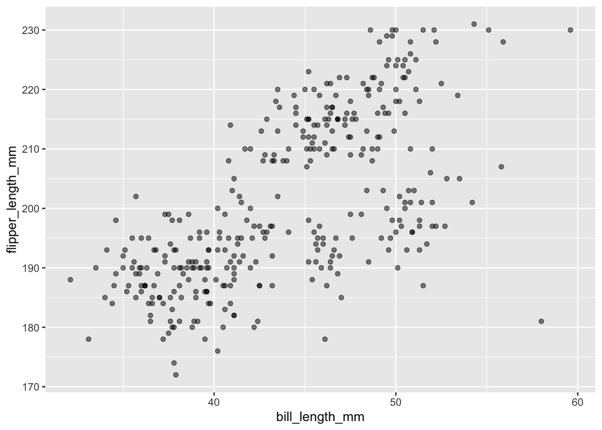

```r
# scatterplot
palmerpenguins::penguins %>%
  select(bill_length_mm, flipper_length_mm) %>%
  ggplot(aes(x=bill_length_mm, y=flipper_length_mm)) +
  geom_point(alpha = .5)
```

2.2 I pick “body mass” and “species”. Histogram and Boxplot are used to visualize these variables.

```r
#descriptive table
palmerpenguins::penguins %>%
  select(species, body_mass_g) %>%
  group_by(species) %>%
  summarize(sample_n = n(),
            mean_bodymass = mean(body_mass_g, na.rm = TRUE),
            sd_bodymass = sd(body_mass_g, na.rm = TRUE))
```

```
## # A tibble: 3 x 4
##   species   sample_n mean_bodymass sd_bodymass
## * <fct>        <int>         <dbl>       <dbl>
## 1 Adelie         152         3701.        459.
## 2 Chinstrap       68         3733.        384.
## 3 Gentoo         124         5076.        504.
```

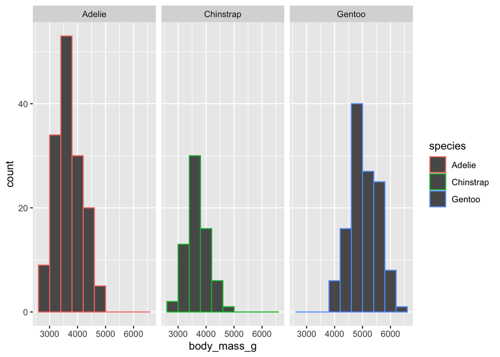

```r
#histogram
palmerpenguins::penguins %>%
  select(species, body_mass_g) %>%
  ggplot(aes(x=body_mass_g, color=species)) +
  geom_histogram(bins=10) +
  facet_wrap(~species)
```

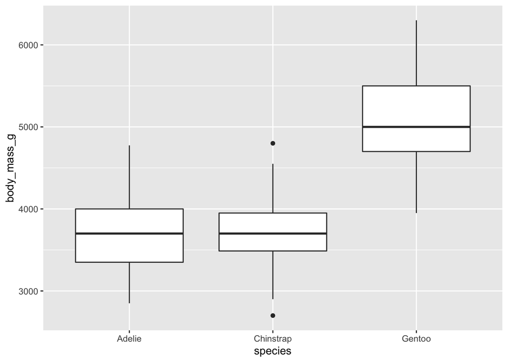

```r
#boxplot
palmerpenguins::penguins %>%
  select(species, body_mass_g) %>%
  ggplot(aes(x=species, y=body_mass_g)) +
  geom_boxplot()
```